# A Visual Story of Petrol Prices

## What is this data about?

For this project, I used a Google Form to record petrol prices . Each row is one observation, including the date, where I saw the price, the price per litre, my opinion about the price, and whether the price affected my decision. This is observational data because I recorded real petrol prices I saw, instead of asking many people questions.

## Where were petrol prices higher?

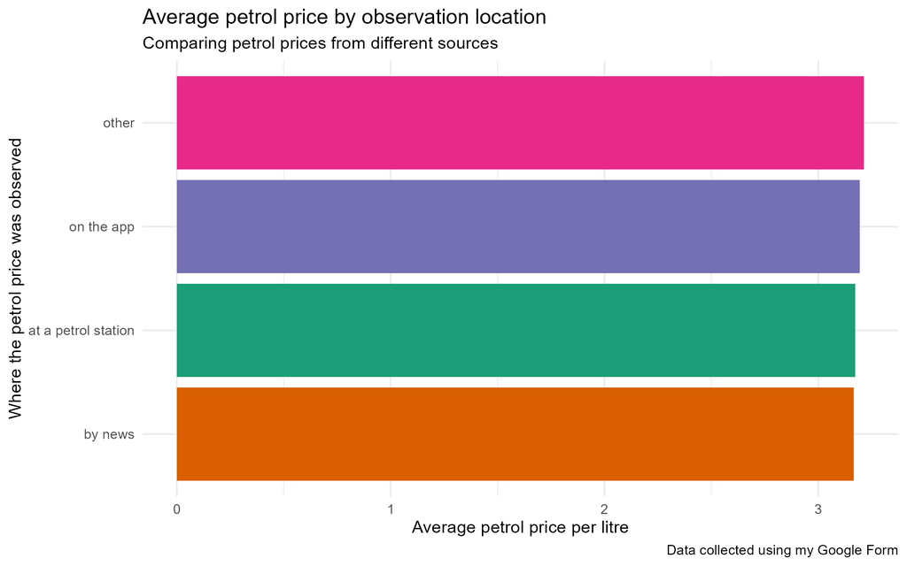

A bar chart showing the average petrol price for each observation location, with locations ordered by average petrol price.

## Did petrol prices change over time?

The second plot shows petrol prices on different dates. I used the date column from my data and changed it into a proper date format using the lubridate package in R. This plot helps me see whether the petrol price stayed similar or changed over time.

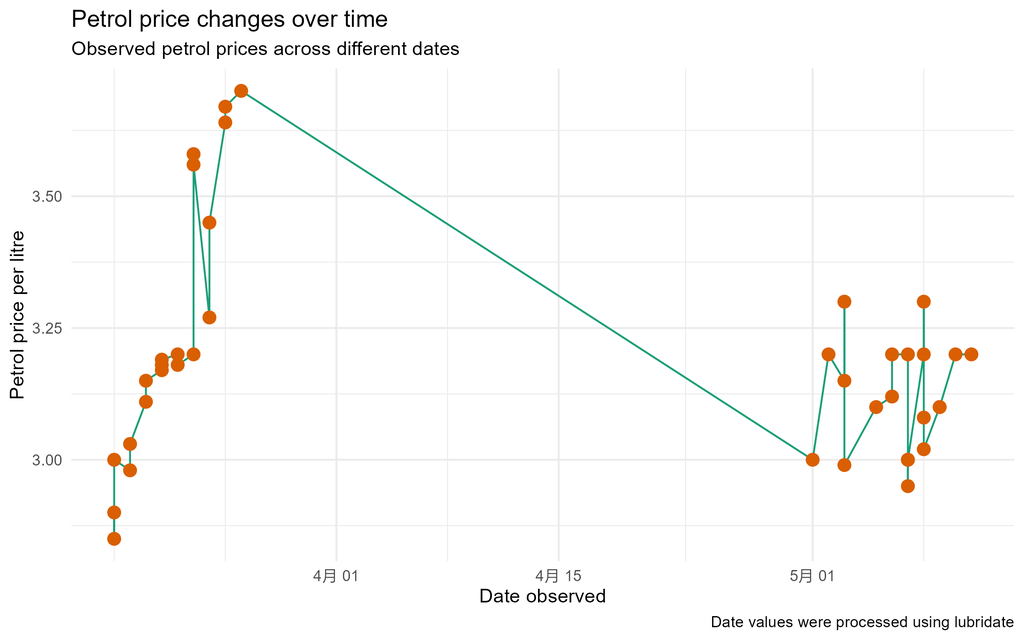

A line and point chart showing petrol prices across different observation dates.

## Did petrol price affect decisions?

The third plot compares petrol prices based on whether the price affected my decision or not. This helps me see whether higher petrol prices were more likely to affect decisions. Since a boxplot shows the spread of prices in each group, it is clearer than only looking at the average.

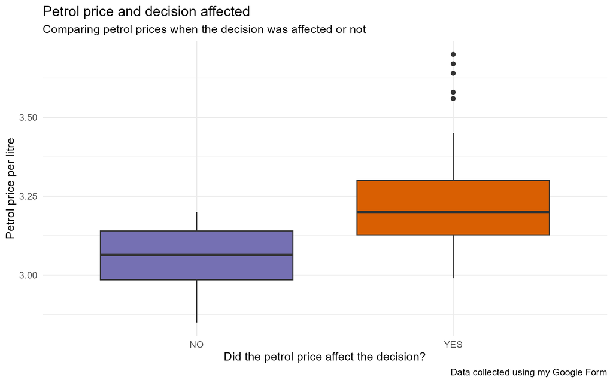

A boxplot comparing petrol prices for observations where the petrol price did or did not affect a decision.

## What does the visual story show?

Overall, this visual story shows that petrol prices can be compared by location, date, and decision. Compared with only looking at the raw table, the plots make the data easier to understand and help show some simple patterns.

Through this project, I learned how to turn observational data into a visual story. The graphs helped me understand the petrol price data better and explain my findings more clearly.